# Generalized Linear Model

Emma Li

# LM

Linear Model makes several key assumptions:

- Linear relationship between X and E(Y) = miu = X*Beta
- Multivariate normality
- No or little multicollinearity
- No auto-correlation
- Error terms exhibit similar amounts of variance

# GLM

Generalized Linear Model is the general case of ordinary linear regression. It allows the response variable to have error distribution model other than normal distribution.

Key Assumptions:

- Linear relationship between X and g(E(Y)) = g(miu) = X*Beta

Depending on the distribution, we haev a link function g().

- No or little multicollinearity.
- No auto-correlation.
- Error terms exhibit similar amounts of variance

## g(E(Y)) = g(miu) = X*Beta

# Distirbutions in Exponential Family

Y can follow Normal Distribution, Bernoulli distribution, binomial distribution, Poisson distribution, negative binomial distribution, Gamma distribution, Tweedie Distribution, Exponential Distirbution, etc.

For example,

1. Poisson distribution when the dependent variable is count in nature (e.g. claim counts).
2. Binomial distribution when the dependent variable is binary (e.g., yes or no).

## g(E(Y)) = g(miu) = X*Beta

# Link Functions

- The domain of the link function is matched to the range of the distribution function’s mean.
- The range of the link function is X*Beta

For example,

1. Poisson distribution when the dependent variable is count in nature (e.g. claim counts).

g() is log function: g(E(Y)) = ln(E(Y)) = X*Beta

# Link Functions

2. Binomial distribution when the dependent variable is binary (e.g., yes or no).

g() is logit function: g(E(Y)) = ln(E(Y)/(1-E(Y))) = X*Beta

or

g() is Inverse CDF: g(E(Y)) = Inverse of Normal CDF(E(Y)) = X*Beta

or

g() is Complementary log-log function: g(E(Y)) = log(-log(1-E(Y))) = X*Beta

## g(E(Y)) = g(miu) = X*Beta

# R Function in stats package

“R functino glm() is used to fit generalized linear models, specified by giving a symbolic description of the linear predictor and a description of the error distribution.”

Inputs: glm(formula, family = gaussian, data, …)

Outputs: summary, coefficents, p values, residuals, fitted values, …

## g(E(Y)) = g(miu) = X*Beta

# Simulated Data

This data set records the numbers of personal auto claims incurred in 2015. The numbers of insured auto, the policyholders’ ages, and their family sizes are also recorded by policy level.

| Variables | Descriptions |
| --- | --- |
| clm | Claim Counts |
| num_car | Number of Insured Personal Auto |
| age | Age of Policyholders |
| familiy_size | Family Size of Policyholders |

```r
rootDir<-"../data-raw/"
clm_cnt <- read.csv(file=paste0(rootDir,"11_GLMs.csv"))
```

# Summary and Graphs

```r
dim(clm_cnt)
```

```
## [1] 240   4
```

```r
colnames(clm_cnt)
```

```
## [1] "clm"         "age"         "num_car"     "family_size"
```

```r
summary(clm_cnt)
```

```
##       clm              age          num_car       family_size
##  Min.   :0.0000   Min.   :15.0   Min.   :1.000   Min.   :1.00
##  1st Qu.:0.0000   1st Qu.:24.0   1st Qu.:1.000   1st Qu.:1.00
##  Median :1.0000   Median :44.5   Median :1.000   Median :1.00
##  Mean   :0.6833   Mean   :44.2   Mean   :1.417   Mean   :1.55
##  3rd Qu.:1.0000   3rd Qu.:61.0   3rd Qu.:2.000   3rd Qu.:2.00
##  Max.   :2.0000   Max.   :74.0   Max.   :4.000   Max.   :4.00
```

```r
apply(clm_cnt,2,table)
```

```
## $clm
##
##   0   1   2
##  81 154   5
##
## $age
##
## 15 16 17 18 19 20 21 22 23 24 26 28 29 30 31 33 34 35 36 37 38 39 40 41 42
##  4  6  3  8  8  4  6  4  6 13  2  2  3  9  5  4  3  3  3  4  2  3  4  3  5
## 43 44 45 47 48 49 50 51 52 53 54 55 56 57 58 59 60 61 62 63 64 66 67 68 69
##  2  1  2  4  4  1  1  4  3  2  8  5  1  8  1  9  5  4  7  5  6  4  7  2  5
## 70 71 72 73 74
##  4  2  4  3  9
##
## $num_car
##
##   1   2   3   4
## 160  63  14   3
##
## $family_size
##
##   1   2   3   4
## 142  68  26   4
```

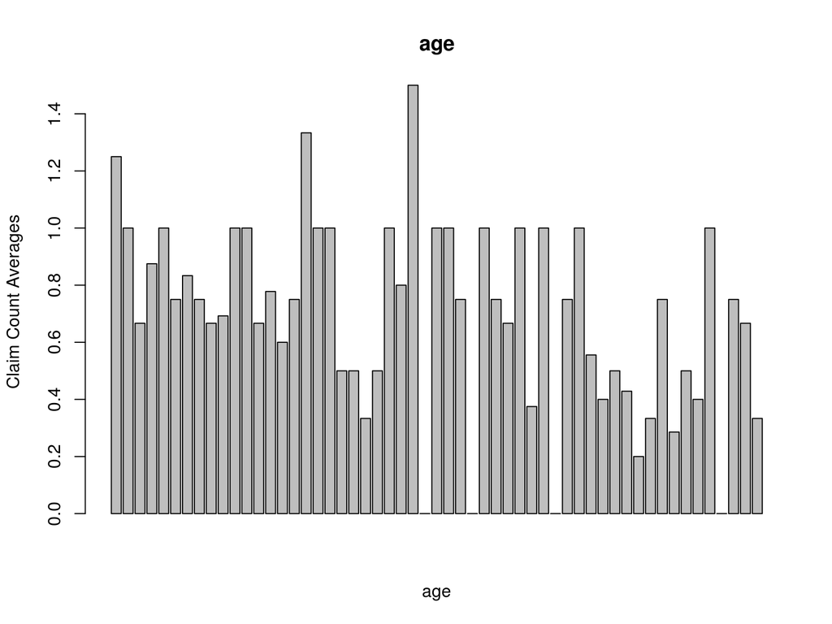

```r
avg<-function(x) {
  data<-aggregate(clm_cnt[,"clm"],by=list(clm_cnt[,x]),FUN=mean)
  barplot(data[,2],main=x,xlab=x,ylab="Claim Count Averages")
}
avg(x="age")
```

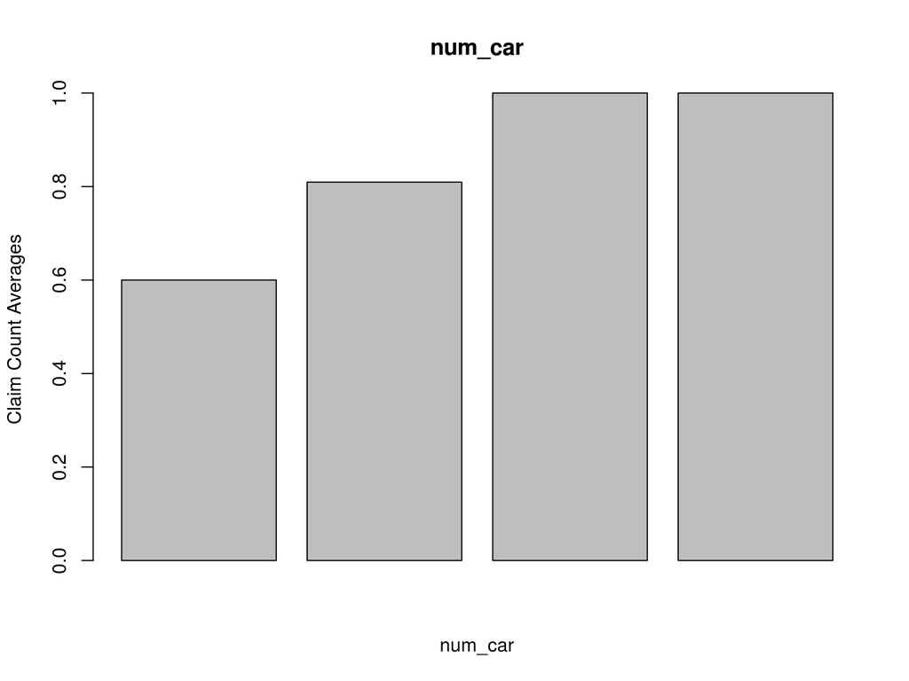

```r
avg(x="num_car")
```

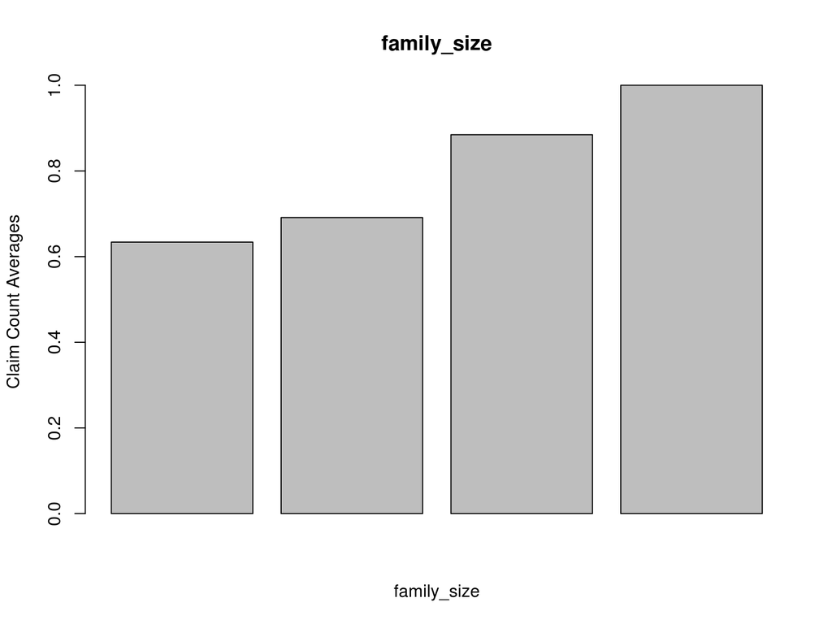

```r
avg(x="family_size")
```

```r
cor(clm_cnt[,-1])
```

```
##                   age    num_car family_size
## age         1.0000000 0.10784077  0.10492571
## num_car     0.1078408 1.00000000  0.02524064
## family_size 0.1049257 0.02524064  1.00000000
```

# Choose distribution and link function

1. Poisson distribution when the dependent variable is count in nature.

log: g(E(Y)) = log(E(Y)) = X*Beta

```r
poisson_reg <- glm(clm~ age+num_car+family_size,   data = clm_cnt,   family = poisson)
summary(poisson_reg)
```

```
##
## Call:
## glm(formula = clm ~ age + num_car + family_size, family = poisson,
##     data = clm_cnt)
##
## Deviance Residuals:
##     Min       1Q   Median       3Q      Max
## -1.2860  -0.9268   0.1221   0.3887   1.8754
##
## Coefficients:
##              Estimate Std. Error z value Pr(>|z|)
## (Intercept) -0.504041   0.275891  -1.827  0.06771 .
## age         -0.013699   0.004294  -3.190  0.00142 **
## num_car      0.277694   0.105531   2.631  0.00850 **
## family_size  0.182568   0.098658   1.851  0.06424 .
## ---
## Signif. codes:  0 '***' 0.001 '**' 0.01 '*' 0.05 '.' 0.1 ' ' 1
##
## (Dispersion parameter for poisson family taken to be 1)
##
##     Null deviance: 138.76  on 239  degrees of freedom
## Residual deviance: 121.24  on 236  degrees of freedom
## AIC: 450.3
##
## Number of Fisher Scoring iterations: 5
```

```r
coef(poisson_reg)
```

```
## (Intercept)         age     num_car family_size
##  -0.5040411  -0.0136992   0.2776940   0.1825675
```

```r
str(poisson_reg)
```

[output not shown]

[output cut: 49 more lines]

[output not shown]

```r
head(poisson_reg$residuals)
```

```
##           1           2           3           4           5           6
##  0.33691566  0.64189857 -1.00000000  0.64189857  0.03702878  2.32909207
```

```r
head(poisson_reg$fitted.values)
```

```
##         1         2         3         4         5         6
## 0.7479903 0.6090510 0.6090510 0.6090510 0.9642934 0.6007644
```

```r
head(poisson_reg$data)
```

```
##   clm age num_car family_size
## 1   1  18       1           1
## 2   1  33       1           1
## 3   0  33       1           1
## 4   1  33       1           1
## 5   1  40       3           1
## 6   2  34       1           1
```

```r
poisson_reg2 <- glm(clm~ age+num_car,   data = clm_cnt,   family = poisson)
summary(poisson_reg2)
```

```
##
## Call:
## glm(formula = clm ~ age + num_car, family = poisson, data = clm_cnt)
##
## Deviance Residuals:
##     Min       1Q   Median       3Q      Max
## -1.2997  -0.9575   0.1825   0.3976   1.7579
##
## Coefficients:
##             Estimate Std. Error z value Pr(>|z|)
## (Intercept) -0.24811    0.23422  -1.059  0.28947
## age         -0.01284    0.00425  -3.022  0.00251 **
## num_car      0.27717    0.10406   2.663  0.00773 **
## ---
## Signif. codes:  0 '***' 0.001 '**' 0.01 '*' 0.05 '.' 0.1 ' ' 1
##
## (Dispersion parameter for poisson family taken to be 1)
##
##     Null deviance: 138.76  on 239  degrees of freedom
## Residual deviance: 124.50  on 237  degrees of freedom
## AIC: 451.57
##
## Number of Fisher Scoring iterations: 5
```

# Alternative distribution and link function

```r
summary(clm_cnt$clm)
```

```
##    Min. 1st Qu.  Median    Mean 3rd Qu.    Max.
##  0.0000  0.0000  1.0000  0.6833  1.0000  2.0000
```

```r
table(clm_cnt$clm)
```

```
##
##   0   1   2
##  81 154   5
```

2. Binomial distribution when the dependent variable is binary (e.g., yes or no).

logit: g(E(Y)) = ln(E(Y)/(1-E(Y))) = X*Beta

```r
clm_cnt$clm_cap <- ifelse(clm_cnt$clm==0,0,1)
logistic_reg <- glm(clm_cap~ age+num_car+family_size,   data= clm_cnt,   family = binomial)
summary(logistic_reg)
```

```
##
## Call:
## glm(formula = clm_cap ~ age + num_car + family_size, family = binomial,
##     data = clm_cnt)
##
## Deviance Residuals:
##     Min       1Q   Median       3Q      Max
## -2.1227  -0.8019   0.3648   0.7832   1.9362
##
## Coefficients:
##              Estimate Std. Error z value Pr(>|z|)
## (Intercept) -0.504757   0.631501  -0.799 0.424117
## age         -0.056771   0.009853  -5.762 8.32e-09 ***
## num_car      1.772574   0.374012   4.739 2.14e-06 ***
## family_size  0.998410   0.258047   3.869 0.000109 ***
## ---
## Signif. codes:  0 '***' 0.001 '**' 0.01 '*' 0.05 '.' 0.1 ' ' 1
##
## (Dispersion parameter for binomial family taken to be 1)
##
##     Null deviance: 306.89  on 239  degrees of freedom
## Residual deviance: 232.63  on 236  degrees of freedom
## AIC: 240.63
##
## Number of Fisher Scoring iterations: 5
```

# Model Selection

AIC=2*k-2*ln(L)

k = the number of parameter

L = the maximized value of the likelihood function of the model M, p(x|X, Beta)

```r
AIC(poisson_reg)
```

```
## [1] 450.3045
```

```r
AIC(poisson_reg2)
```

```
## [1] 451.5671
```

```r
AIC(logistic_reg)
```

```
## [1] 240.6336
```

BIC=k*ln(n)-2*ln(L)

k = the number of parameter

L = the maximized value of the likelihood function of the model M, p(x|X, Beta)

n = the number of observations

```r
BIC(poisson_reg)
```

```
## [1] 464.2271
```

```r
BIC(poisson_reg2)
```

```
## [1] 462.009
```

```r
BIC(logistic_reg)
```

```
## [1] 254.5562
```

The BIC generally penalizes the number of parameters more strongly than the AIC, because k is multiplied by a larger number, ln(n), in BIC than by 2 in AIC

# Reference

https://en.wikipedia.org/wiki/Generalized_linear_model#Link_function https://stat.ethz.ch/R-manual/R-devel/library/stats/html/glm.html